# Graph Basics

A **graph** (considering undirected graphs only for now) is a pair $G=(V,E)$ of sets where $V=V(G)$ is the set of vertices(or nodes) and $E=E(G)$ is a multiset(allowing repeats) of edges where an edge is a 2-multisubset of V.

- $G=(V,E)$ is a **finite graph** if both $V$ and $E$ are finite.
- A **multigraph** is a graphs with multiedges (multiple edges joining two vertices).
- A **simple graph** is a graph without multiedges.

See the examples below for how to plot a graph in python using networkx:

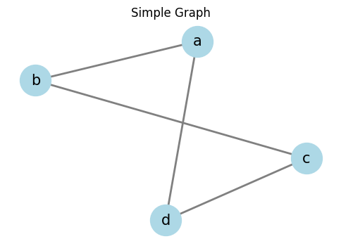

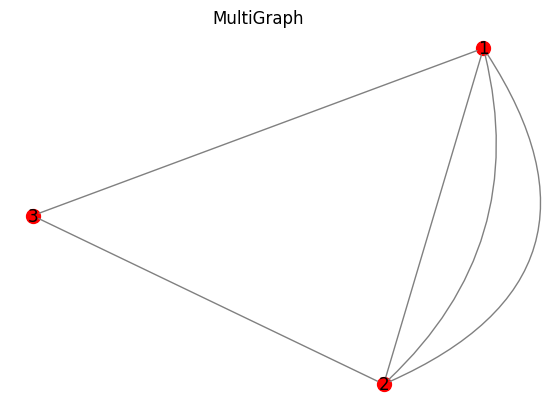

```python
import networkx as nx
import matplotlib.pyplot as plt

# Example 1: A Simple Graph
G_simple = nx.Graph()
G_simple.add_nodes_from(['a', 'b', 'c', 'd'])
G_simple.add_edges_from([('a', 'b'), ('b', 'c'), ('c', 'd'), ('d', 'a')])

plt.figure(figsize=(6, 4))
plt.title("Simple Graph")
nx.draw(G_simple, with_labels=True, node_size=1000, node_color='lightblue', font_size=15, width=2, edge_color='gray')
plt.show()


# Example 2: A Multigraph (with multiple edges between some nodes)

G = nx.MultiGraph([(1,2),(1,2),(1,2),(3,1),(3,2)])
pos = nx.random_layout(G)

nx.draw_networkx_nodes(G, pos, node_color='r', node_size=100, alpha=1)
ax = plt.gca()

for e in G.edges:
    ax.annotate("",
                xy=pos[e[0]], xycoords='data',
                xytext=pos[e[1]], textcoords='data',
                arrowprops=dict(arrowstyle="-", color="0.5",
                                shrinkA=5, shrinkB=5,
                                patchA=None, patchB=None,
                                connectionstyle="arc3,rad=rrr".replace('rrr', str(0.3*e[2])),
                                ),
                )

# Adding the labels
labels = {}
for node in G.nodes():
    labels[node] = str(node)
nx.draw_networkx_labels(G, pos, labels, font_size=12)

plt.title('MultiGraph')
plt.axis('off')
plt.show()
```

## More Definitions

- Two edges joined by an edge are called neighbors and are said to be **adjacent**. For example, in the simple graph above, $c$ and $d$ are adjacent, $a$ and $b$ as well, but $a$ and $c$ are not adjacent.
- If an edge $e$ contains a vertex $v$, $v,e$ are **incident**.
- For a vertex $v_1$, the number of edges incident to $v_1$ is the **degree** of $v_1$, denoted by $deg(v_1)$. For example, the vertex $c$ in the simple graph above has a degree of 2, or $deg(c)=2$

## The Handshaking Lemma

Let $G$ be a finite graph (simple or multigraph). Then the sum of all degrees of vertices is the twice of the number of edges. Namely,

$$ \sum_{v \in V} deg(v) = 2|E| $$ where $|E|$ denotes the number of edges in a graph. An immediate corollary is as follows: In any graph, there must be an even number of vertices with odd degrees.

## Complete Graph

A **complete graph** on $n$ vertices $K_n$ is a simple graph where every two vertices are joined. Here is an example:

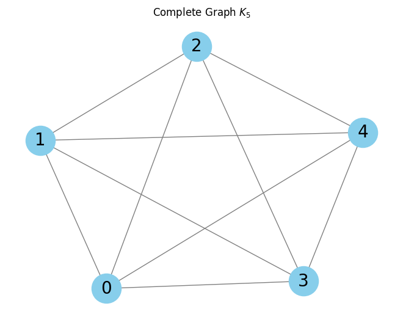

```python
# Create a complete graph with 5 vertices
G = nx.complete_graph(5)

# Draw the graph
pos = nx.spring_layout(G)
nx.draw(G, pos, with_labels=True, node_color='skyblue', edge_color='gray', node_size=1200, font_size=20)

plt.title("Complete Graph $K_5$")
plt.show()
```

## $K$-Regular Graph

If each vertex in $G$ has a degree $k$, then the graph is $k$-regular.

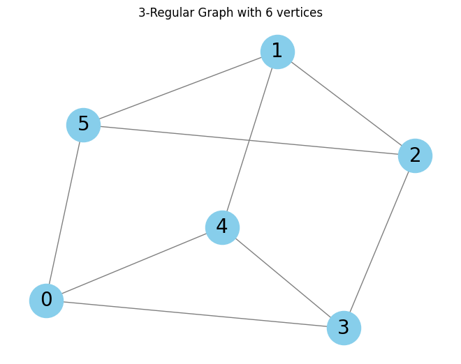

```python
import networkx as nx
import matplotlib.pyplot as plt

# Generate a 3-regular graph (also known as cubic graph) with 6 vertices
G = nx.random_regular_graph(3, 6)

# Draw the graph
pos = nx.spring_layout(G)
nx.draw(G, pos, with_labels=True, node_color='skyblue', edge_color='gray', node_size=1200, font_size=20)

plt.title("3-Regular Graph with 6 vertices")
plt.show()
```

### Hypercubes

A **hypercube** or a **$n$-cube** $Q_n$ has the form of $$Q_n=(V,E)$$ where $V$ is the colletion of all binary sequences of length $n$. Each vertex has a degree of $n$, or the graph is $n$-regular. For example, consider the three dimensional case. We first plot a cube:

[figure not shown]

```python
import matplotlib.pyplot as plt
from mpl_toolkits.mplot3d import Axes3D

# Vertices based on binary sequences for 3-cube
vertices = [
    (0, 0, 0), # 000
    (0, 0, 1), # 001
    (0, 1, 0), # 010
    (0, 1, 1), # 011
    (1, 0, 0), # 100
    (1, 0, 1), # 101
    (1, 1, 0), # 110
    (1, 1, 1)  # 111
]

edges = [
    (0, 1), (0, 2), (0, 4),
    (7, 6), (7, 5), (7, 3),
    (1, 3), (1, 5),
    (2, 3), (2, 6),
    (4, 5), (4, 6)
]

fig = plt.figure()
ax = fig.add_subplot(111, projection='3d')

# Plot vertices
ax.scatter3D(*zip(*vertices), color='blue')

# Plot edges
for start, end in edges:
    line = [*zip(vertices[start], vertices[end])]
    ax.plot3D(*line, color='red')

ax.set_xlabel('X-axis (First bit)')
ax.set_ylabel('Y-axis (Second bit)')
ax.set_zlabel('Z-axis (Third bit)')
ax.set_title('3-Cube')

plt.show()
```

Note that each vertices can be labeled as

| Vertex | Binary Representation |
| --- | --- |
| $v_1$ | 000 |
| $v_2$ | 001 |
| $v_3$ | 010 |
| $v_4$ | 011 |
| $v_5$ | 100 |
| $v_6$ | 101 |
| $v_7$ | 110 |
| $v_8$ | 111 |

Similar ideas can be generalized to other dimensions.

### Constructing Hypercubes

In addition, we can construct $Q_{n+1}$ from $Q_n$. We do so by first making two copies of $Q_n$, then connecting the same vertices and add $1,0$ to the binary sequence of each vertex of each copy. Using $Q_3$ example above to construct $Q_4$

| Vertex | Binary Representation |
| --- | --- |
| $v_1$ | 0000 |
| $v_2$ | 0010 |
| $v_3$ | 0100 |
| $v_4$ | 0110 |
| $v_5$ | 1000 |
| $v_6$ | 1010 |
| $v_7$ | 1100 |
| $v_8$ | 1110 |
| $v_9$ | 0001 |
| $v_{10}$ | 0011 |
| $v_{11}$ | 0101 |
| $v_{12}$ | 0111 |
| $v_{13}$ | 1001 |
| $v_{14}$ | 1011 |
| $v_{15}$ | 1101 |
| $v_{16}$ | 1111 |

## Complete Bipartite Graph

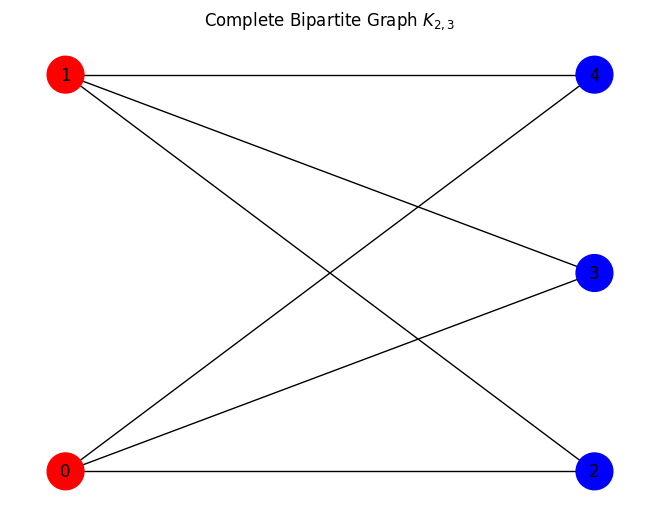

```python
import networkx as nx
import matplotlib.pyplot as plt

# Create a complete bipartite graph K_{2,3}
B = nx.complete_bipartite_graph(2, 3)

# Draw the graph
pos = nx.bipartite_layout(B, [0, 1])  # Here, [0, 1] is the list of nodes in the first partite set
nx.draw(B, pos, with_labels=True, node_size=700, node_color=['red']*2 + ['blue']*3)
plt.title("Complete Bipartite Graph $K_{2,3}$")
plt.show()
```

## Isomorphisms

Let $G,H$ be two graphs. Then $G$ and $H$ are **isomorphic** if there exists a bijection $$P: V(G) \longrightarrow V(H)$$ such that $$\{v,w\}\in E(G) \Longleftrightarrow \{P(v), P(w)\}\in E(H)$$Roughly speaking, $H$ and $G$ are isomorphic if a drawing of one can be moved around to obtain the drawing of the other such that no edges are created or destroyed. In the example below, $G_1$ and $H_1$ are isomorphic, so are $G_2$ and $H_2$, but not $G_3$ and $H_3$.

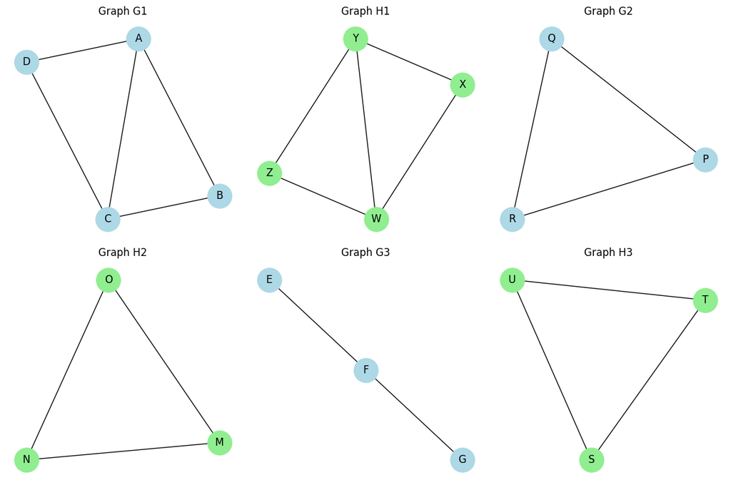

```python
import networkx as nx
import matplotlib.pyplot as plt

# Define the graphs
G1 = nx.Graph([( 'A', 'B'), ('B', 'C'), ('C', 'D'), ('D', 'A'), ('A', 'C')])
H1 = nx.Graph([( 'W', 'X'), ('X', 'Y'), ('Y', 'Z'), ('Z', 'W'), ('W', 'Y')])

G2 = nx.Graph([('P', 'Q'), ('Q', 'R'), ('R', 'P')])
H2 = nx.Graph([('M', 'N'), ('N', 'O'), ('O', 'M')])

G3 = nx.Graph([('E', 'F'), ('F', 'G')])
H3 = nx.Graph([('S', 'T'), ('T', 'U'), ('U', 'S')])

# Plot the graphs
plt.figure(figsize=(12, 8))
plt.subplot(231)
nx.draw(G1, with_labels=True, node_color='lightblue', node_size=800)
plt.title("Graph G1")

plt.subplot(232)
nx.draw(H1, with_labels=True, node_color='lightgreen', node_size=800)
plt.title("Graph H1")

plt.subplot(233)
nx.draw(G2, with_labels=True, node_color='lightblue', node_size=800)
plt.title("Graph G2")

plt.subplot(234)
nx.draw(H2, with_labels=True, node_color='lightgreen', node_size=800)
plt.title("Graph H2")

plt.subplot(235)
nx.draw(G3, with_labels=True, node_color='lightblue', node_size=800)
plt.title("Graph G3")

plt.subplot(236)
nx.draw(H3, with_labels=True, node_color='lightgreen', node_size=800)
plt.title("Graph H3")

plt.tight_layout()
plt.show()
```

In general, given two graphs $G$ and $H$, determining whether they are isomorphic is a hard problem. But, some easy properties can show that two graphs are *not* isomorphic. For example, $H$ and $G$ have different number of edges, vertices or have vertices that differ in degrees.

## Subgraphs

Let $G$ be a graph. Then we say $H$ is a **subgraph** of $G$ if $V(H)\subseteq V(G)$ and $E(H) \subseteq E(G)$ where $e=\{v,w\}\in E(H) \implies v,w\in V(H)$.

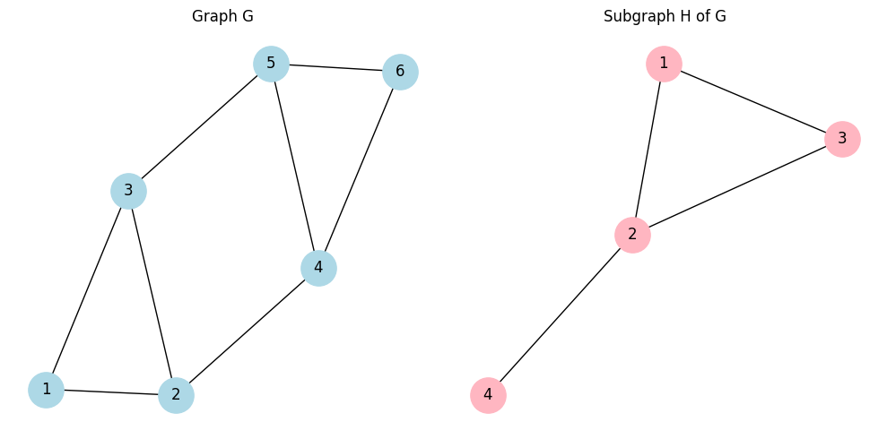

```python
import networkx as nx
import matplotlib.pyplot as plt

# Define the graph G
G = nx.Graph([(1, 2), (1, 3), (2, 3), (2, 4), (3, 5), (4, 5), (4, 6), (5, 6)])

# Create a subgraph of G
sub_nodes = [1, 2, 3, 4]
H = G.subgraph(sub_nodes)

# Plot the graphs
plt.figure(figsize=(10, 5))
plt.subplot(121)
nx.draw(G, with_labels=True, node_color='lightblue', node_size=800)
plt.title("Graph G")

plt.subplot(122)
nx.draw(H, with_labels=True, node_color='lightpink', node_size=800)
plt.title("Subgraph H of G")

plt.tight_layout()
plt.show()
```

Furthermore, an **induced subgraph** is constructed by picking a $V(H)\subseteq V(G)$ and including all edges of $G\in E(H)$ with end points in $V(H)$. Here is an example induced subgraph of $G$ above with the subset $\{1,2,3,4\}$ of $V$:

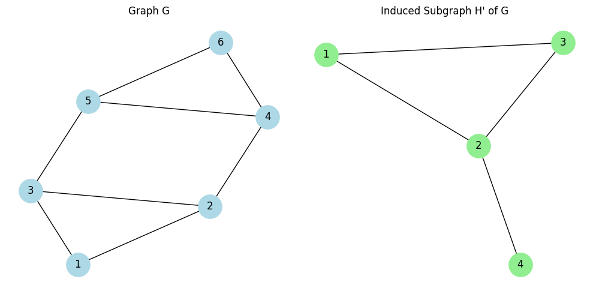

```python
import networkx as nx
import matplotlib.pyplot as plt

# Define the graph G
G = nx.Graph([(1, 2), (1, 3), (2, 3), (2, 4), (3, 5), (4, 5), (4, 6), (5, 6)])

# Create an induced subgraph of G
induced_nodes = [1, 2, 3, 4]
H_prime = G.subgraph(induced_nodes).copy()

# Plot the graphs
plt.figure(figsize=(10, 5))
plt.subplot(121)
nx.draw(G, with_labels=True, node_color='lightblue', node_size=800)
plt.title("Graph G")

plt.subplot(122)
nx.draw(H_prime, with_labels=True, node_color='lightgreen', node_size=800)
plt.title("Induced Subgraph H' of G")

plt.tight_layout()
plt.show()
```

Subgraphs can be used in isomorphism problems.